# Milestone 4 Regression Diagnostics

Author

Kyle Castillo

Published

April 29, 2024

```r
knitr::opts_chunk$set(
  message=FALSE,
  echo=FALSE
)
```

## Obtaining the data

This dataset was originally compiled by Dean De Cock for the purpose of improving the predictive accuracy of housing prices. With 2,925 observations and over 80 attributes, the dataset offers a comprehensive view of the real estate market in a mid-sized American city during this period.

The dataset includes a wide range of variables that describe almost every aspect of residential homes, such as the type of dwelling, the size of the lot, the quality and condition of the house, the number of rooms, type of heating, and more. These variables are categorized into various groups like general, location, space, and quality metrics, which allow for detailed analysis and modeling, particularly useful for predicting house prices.

## Data Dictionary

```
# A tibble: 2,680 × 21
   MSSubClass MSZoning LotArea Neighborhood BldgType HouseStyle OverallQual
   <chr>      <chr>      <dbl> <chr>        <chr>    <chr>            <dbl>
 1 020        RL         47007 Edwards      1Fam     1Story               5
 2 075        RL         19800 Edwards      1Fam     2.5Unf               6
 3 060        RL         35760 NoRidge      1Fam     2Story              10
 4 060        RL         17242 NoRidge      1Fam     2Story               9
 5 050        RL         14100 Crawfor      1Fam     1.5Fin               8
 6 060        RL         18062 StoneBr      1Fam     2Story              10
 7 050        RL         14720 NoRidge      1Fam     1.5Fin               8
 8 020        RL         12692 NoRidge      1Fam     1Story               8
 9 060        RL         12376 SawyerW      1Fam     2Story               7
10 070        RL         12168 Crawfor      1Fam     2Story               8
# ℹ 2,670 more rows
# ℹ 14 more variables: OverallCond <dbl>, YearBuilt <dbl>,
#   `YearRemod/Add` <dbl>, Exterior1st <chr>, ExterQual <chr>, ExterCond <chr>,
#   Foundation <chr>, Heating <chr>, Electrical <chr>, KitchenQual <chr>,
#   GarageArea <dbl>, Functional <chr>, YrSold <dbl>, SalePrice <dbl>
```

**MSSubClass**: Identifies the type of dwelling involved in the sale
**MSZoning**: Identifies the general zoning classification of the sale
**LotArea**: Lot size in square feet
**Neighborhood**: Physical locations within Ames city limits
**BldgType**: Type of dwelling
**HouseStyle**: Style of dwelling
**OverallQual**: Rates the overall material and finish of the house
**OverallCond**: Rates the overall condition of the house
**YearBuilt**: Original construction date
**YearRemod/Add**: Remodel date
**Exterior1st**: Exterior covering on house
**ExterQual**: Evaluates the quality of the material on the exterior
**ExterCond**: Evaluates the present condition of the material on the exterior
**Heating**: Type of heating
**Electrical**: Electrical system
**KitchenQual**: Kitchen quality
**Garage Area**: Size of garage in square feet
**Functional**: Home functionality
**YrSold**: Year Sold (YYYY)
**SalePrice**: Sale price $$

## Part 1: Numerical Description

#### Neighborhood vs. Average Sale Price

```
# A tibble: 28 × 2
   Neighborhood avgSalePrice
   <fct>               <dbl>
 1 NoRidge           296944.
 2 NridgHt           287856.
 3 GrnHill           280000
 4 StoneBr           271878.
 5 Veenker           242372.
 6 Timber            240992.
 7 Somerst           225230.
 8 Crawfor           214105.
 9 ClearCr           202125.
10 CollgCr           199931.
# ℹ 18 more rows
```

This code makes a tibble, hoodSale, showing the average sale price of each property correlated to the neighborhood its in. By using various functions such as head() and tail() we can see the neighborhoods that contain the highest selling properties vs the lowest selling properties. Additionally we filter out properties that sold for over $400,000 and under $60,000 in order avoid extreme outliers and focus on properties within a reasonable price range.

```
# A tibble: 6 × 2
  Neighborhood avgSalePrice
  <fct>               <dbl>
1 NoRidge           296944.
2 NridgHt           287856.
3 GrnHill           280000
4 StoneBr           271878.
5 Veenker           242372.
6 Timber            240992.
```

```
# A tibble: 6 × 2
  Neighborhood avgSalePrice
  <fct>               <dbl>
1 Edwards           132198.
2 BrkSide           123840.
3 OldTown           119682.
4 IDOTRR            118816.
5 BrDale            105608.
6 MeadowV            95756.
```

As shown by this data, the neighborhoods that contain the highest selling properties include, Northridge, Northridge Heights, and Green Hills. The neighborhoods that include the lowest selling properties include Meadow Village, Briardale, and Iowa DOT and Rail Road.

#### Neighborhood vs. Average Year Built

```
# A tibble: 28 × 2
   Neighborhood avgYear
   <fct>          <dbl>
 1 NridgHt        2006.
 2 Blmngtn        2005.
 3 Somerst        2005.
 4 StoneBr        1999.
 5 Gilbert        1998.
 6 CollgCr        1998.
 7 Timber         1997.
 8 NoRidge        1995.
 9 Landmrk        1993
10 SawyerW        1992.
# ℹ 18 more rows
```

```
# A tibble: 28 × 3
   Neighborhood avgYear avgSalePrice
   <fct>          <dbl>        <dbl>
 1 NridgHt        2006.      287856.
 2 Blmngtn        2005.      196662.
 3 Somerst        2005.      225230.
 4 StoneBr        1999.      271878.
 5 Gilbert        1998.      190647.
 6 CollgCr        1998.      199931.
 7 Timber         1997.      240992.
 8 NoRidge        1995.      296944.
 9 Landmrk        1993       137000
10 SawyerW        1992.      185834.
# ℹ 18 more rows
```

```
# A tibble: 6 × 3
  Neighborhood avgYear avgSalePrice
  <fct>          <dbl>        <dbl>
1 NridgHt        2006.      287856.
2 Blmngtn        2005.      196662.
3 Somerst        2005.      225230.
4 StoneBr        1999.      271878.
5 Gilbert        1998.      190647.
6 CollgCr        1998.      199931.
```

2 neighborhoods found in the top 5 on both tibbles so far are Northridge Heights and Stone Brook. Overall, the average year the 5 newest neighborhoods were built in was `2003` and the average sale price of properties in these neighborhoods is `234454.4`.

```
# A tibble: 6 × 3
  Neighborhood avgYear avgSalePrice
  <fct>          <dbl>        <dbl>
1 NAmes          1960.      145076.
2 Crawfor        1951.      214105.
3 OldTown        1940.      119682.
4 IDOTRR         1937.      118816.
5 SWISU          1936.      135080.
6 BrkSide        1935.      123840.
```

#### Type of Foundation vs. Exterior Quanity

```
           Ex   Fa   Gd   TA  Sum
  BrkTil    0    2   15  166  183
  CBlock    7   12  109 1058 1186
  PConc    92    1  831  331 1255
  Slab      0    4    1   44   49
  Stone     1    0    1    0    2
  Wood      0    0    2    3    5
  Sum     100   19  959 1602 2680
```

This table shows attempts to show a correlation between the material used on the foundation of the property and the overall exterior quality. As seen by the table, poured concrete is the most popular material with cinder block being a close second. However, what is interesting is that poured concrete performs significantly better with `66.2151394` % of observations being classified as ‘Good’ compared to `9.1905565`% properties with cinder block foundations. Furthermore, poured concrete has 92 entries classified as ‘Excellent’. The most of any material by far.

#### Heating vs. Average Year Built

```
# A tibble: 5 × 3
  Heating avgYear heatCount
  <fct>     <dbl>     <int>
1 GasA      1977.      2656
2 GasW      1951.        11
3 Wall      1949.         6
4 Floor     1949          1
5 Grav      1932.         6
```

I was curious to see if the type of heating used in properties correlated to the average year of construction. From this tibble, it seems that GasA or “Gas forced warm air furnace” as defined by the metadata is by far the most popular. It is also the newest method of heating by 26 years on average.

#### House Style vs. Average Year Built

```
# A tibble: 8 × 3
  HouseStyle avgYear count
  <fct>        <dbl> <int>
1 2Story       1988.   772
2 SFoyer       1977.    83
3 1Story       1977.  1435
4 SLvl         1976.   128
5 1.5Fin       1943.   236
6 2.5Unf       1942.     7
7 1.5Unf       1936.    17
8 2.5Fin       1930.     2
```

With my final tibble, I was interested in discovering the correlation between the year each property was constructed and the style of house built. As seen by the table, 2 story homes are trending with 772 of them being constructed with the average year of construction being 1988. Single story homes are going out of style, but are the most popular type of homes present. There were 1435 at the moment this study was published, however, the average date of their construction goes back to 1976.

## Part 2: Visual Description

#### Year Built vs. Garage Area

For my first graph I decided to take a look at the correlation between garage size and the year built. However, prior to plotting the data, I filtered out homes with no garages in order to not skew the data.

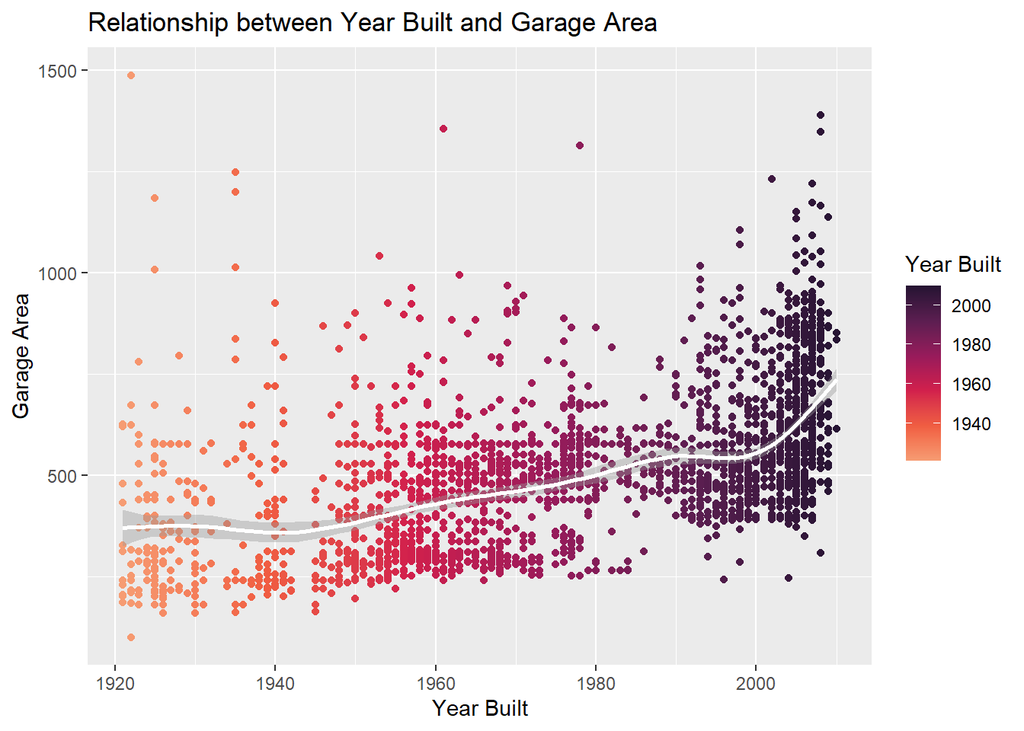

As seen by the graph, garages seems to be increasing along with the year they are constructed. Although the trend isn’t happening particularly quickly, evidence does show garages growing with time.

#### Kitchen Quality vs. Sale Price

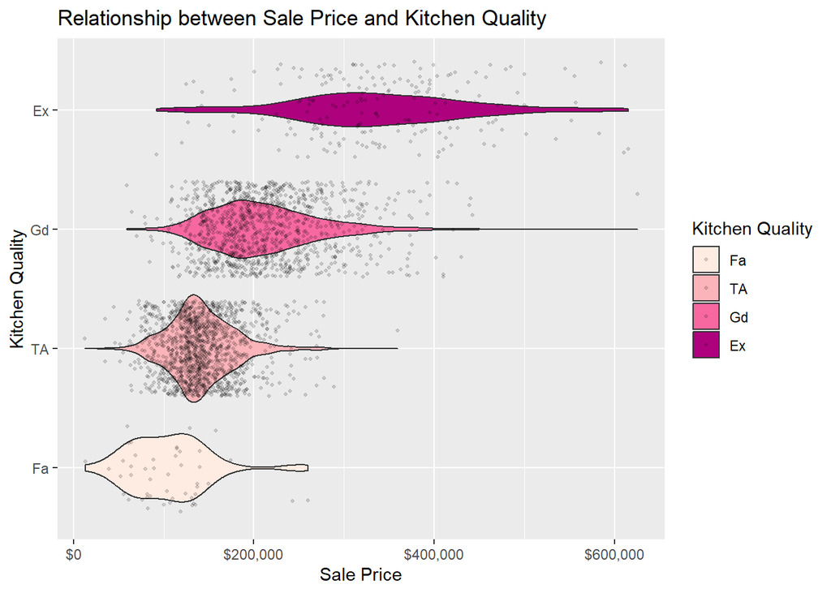

The graph displays the sale price of homes in relation to the quality of their kitchen. Generally, homes with higher quality kitchens have a larger Sale Price.

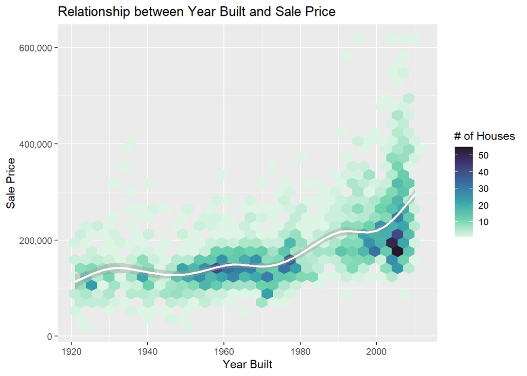

As years progress, the sale price of properties rise with it. However, it seems that house prices are rising faster, as the line of best fit has gotten steeper recently.

This graph compares the type of foundation found in each property to the year they were built. It goes hand in hand with a table found in Milestone 1 investigating the effectiveness of each material. The tibble is below

```
           Ex   Fa   Gd   TA  Sum
  BrkTil    0    2   15  166  183
  CBlock    7   12  109 1058 1186
  PConc    92    1  831  331 1255
  Slab      0    4    1   44   49
  Stone     1    0    1    0    2
  Wood      0    0    2    3    5
  Sum     100   19  959 1602 2680
```

Although cinder blocks and poured concrete were used nearly an equal amount, poured concrete performs significantly better.

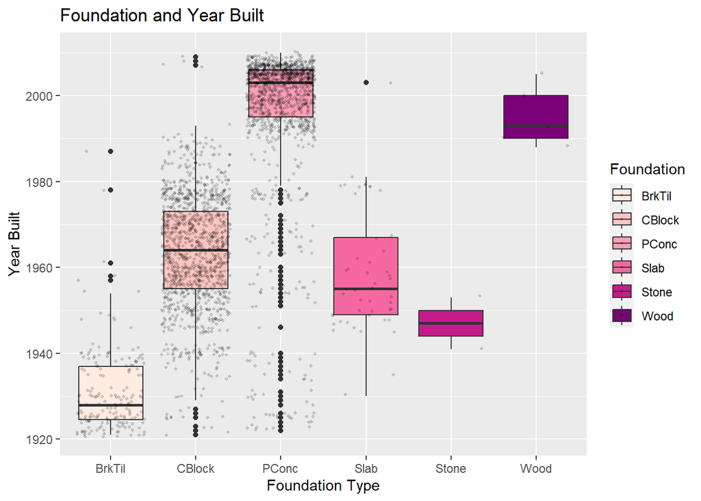

A possible explanation for this could be that on average, homes that use poured concrete were built a lot more recently, while homes that use cinder block were built in the mid 60s. It is possible that the only reason poured concrete perform better is because it was used more recently.

#### Sale Price by Neighborhood

This graph is a box plot of homes correlated to their respective sale price whilst grouped by the neighborhood they are in.

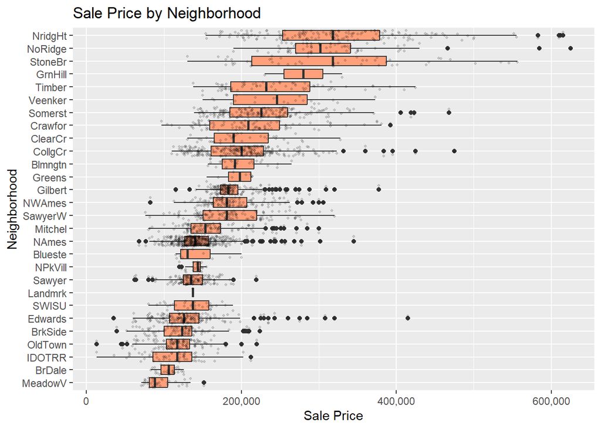

# Part 3: Regression Analysis

When thinking of `SalePrice`, the first attributes that come to mind are `OverallQual`, `YearBuilt`, `LotArea`, and maybe `Neighborhood`.

#### SalePrice vs OverallQual

Lets start by finding the correlation between `SalePrice` and `OverallQual`

```
Call:
lm(formula = SalePrice ~ OverallQual, data = df)

Residuals:
    Min      1Q  Median      3Q     Max
-163737  -28583   -2631   21263  297920

Coefficients:
            Estimate Std. Error t value Pr(>|t|)
(Intercept) -95774.5     4029.5  -23.77   <2e-16 ***
OverallQual  45501.3      638.1   71.30   <2e-16 ***
---
Signif. codes:  0 '***' 0.001 '**' 0.01 '*' 0.05 '.' 0.1 ' ' 1

Residual standard error: 45860 on 2678 degrees of freedom
Multiple R-squared:  0.655, Adjusted R-squared:  0.6549
F-statistic:  5084 on 1 and 2678 DF,  p-value: < 2.2e-16
```

With the p-value of both `OverallQual` and the intercept being less than .05, correlations between these two variables is certain. Additionally, the strong R-squared value , `0.655`, states that approximately 65.5% of the variability in `SalePrice` can be explained by the Overall Quality of the house. This model proves that higher quality homes tend to sell for higher prices.

#### SalePrice vs YearBuilt

Next, lets analyze the correlation between the `YearBuilt` and `SalePrice` attributes. A graph in Milestone 2 already shows a relationship between `YearBuilt` and `SalePrice`, however I want to take a closer look.

```
Call:
lm(formula = SalePrice ~ YearBuilt, data = df)

Residuals:
    Min      1Q  Median      3Q     Max
-153549  -39888  -11800   21818  406997

Coefficients:
              Estimate Std. Error t value Pr(>|t|)
(Intercept) -3417711.0    96067.5  -35.58   <2e-16 ***
YearBuilt       1822.4       48.6   37.50   <2e-16 ***
---
Signif. codes:  0 '***' 0.001 '**' 0.01 '*' 0.05 '.' 0.1 ' ' 1

Residual standard error: 63220 on 2678 degrees of freedom
Multiple R-squared:  0.3443,    Adjusted R-squared:  0.3441
F-statistic:  1406 on 1 and 2678 DF,  p-value: < 2.2e-16
```

#### SalePrice vs. LotArea

I am a little skeptical regarding the correlation between `SalePrice` and `LotArea`. Logically, a home with a lot of land *should* sell for more than an identical home with less land, however, there are probably additional variables at play here. I decided that it was integral I take a look.

```
Call:
lm(formula = SalePrice ~ LotArea, data = df)

Residuals:
    Min      1Q  Median      3Q     Max
-278229  -46890  -16609   33352  412796

Coefficients:
             Estimate Std. Error t value Pr(>|t|)
(Intercept) 1.253e+05  3.391e+03   36.94   <2e-16 ***
LotArea     6.048e+00  3.146e-01   19.22   <2e-16 ***
---
Signif. codes:  0 '***' 0.001 '**' 0.01 '*' 0.05 '.' 0.1 ' ' 1

Residual standard error: 73190 on 2678 degrees of freedom
Multiple R-squared:  0.1212,    Adjusted R-squared:  0.1209
F-statistic: 369.5 on 1 and 2678 DF,  p-value: < 2.2e-16
```

Surprisingly, `LotArea` plays a smaller role in predicting `SalePrice` than I expected. The R-squared value of `0.1212`, or 12.12%, suggests that lot area alone explains only a small portion of the variability in sale prices, highlighting the influence of other factors not captured by this model. However, there is still evidence of a modest correlation. The coefficient for `LotArea` is `6.048`, meaning for each additional square foot in lot area, the sale price increases by approximately $6.05

#### SalePrice vs Neighborhood

For our last test, lets analyze the `SalePrice` attribute compared to its respective `Neighborhood` I predict there will be a particularly strong correlation, mainly due to a box plot in Milestone 2 showing a correlation between average `SalePrice` and type of `Neighborhood`.

```
Call:
lm(formula = SalePrice ~ Neighborhood, data = df)

Residuals:
    Min      1Q  Median      3Q     Max
-184410  -26076   -4452   20165  306846

Coefficients:
                    Estimate Std. Error t value Pr(>|t|)
(Intercept)           196662       9610  20.465  < 2e-16 ***
NeighborhoodBlueste   -53072      18733  -2.833  0.00464 **
NeighborhoodBrDale    -91053      13362  -6.814 1.17e-11 ***
NeighborhoodBrkSide   -75165      10948  -6.866 8.21e-12 ***
NeighborhoodClearCr     5464      12737   0.429  0.66799
NeighborhoodCollgCr     5142      10101   0.509  0.61077
NeighborhoodCrawfor    17443      11003   1.585  0.11303
NeighborhoodEdwards   -63808      10358  -6.160 8.37e-10 ***
NeighborhoodGilbert    -6015      10393  -0.579  0.56280
NeighborhoodGreens     -3130      20385  -0.154  0.87797
NeighborhoodGrnHill    83338      37218   2.239  0.02523 *
NeighborhoodIDOTRR    -85550      11702  -7.311 3.49e-13 ***
NeighborhoodLandmrk   -59662      51750  -1.153  0.24906
NeighborhoodMeadowV  -100905      12737  -7.922 3.40e-15 ***
NeighborhoodMitchel   -34435      10725  -3.211  0.00134 **
NeighborhoodNAmes     -51586       9911  -5.205 2.09e-07 ***
NeighborhoodNoRidge   121493      11394  10.663  < 2e-16 ***
NeighborhoodNPkVill   -55951      14310  -3.910 9.46e-05 ***
NeighborhoodNridgHt   125357      10389  12.067  < 2e-16 ***
NeighborhoodNWAmes     -8255      10587  -0.780  0.43563
NeighborhoodOldTown   -80427      10754  -7.479 1.01e-13 ***
NeighborhoodSawyer    -59316      10485  -5.657 1.70e-08 ***
NeighborhoodSawyerW   -10828      10656  -1.016  0.30966
NeighborhoodSomerst    33046      10322   3.201  0.00138 **
NeighborhoodStoneBr   117749      12046   9.775  < 2e-16 ***
NeighborhoodSWISU     -61582      12893  -4.776 1.88e-06 ***
NeighborhoodTimber     49522      11418   4.337 1.50e-05 ***
NeighborhoodVeenker    45710      14310   3.194  0.00142 **
---
Signif. codes:  0 '***' 0.001 '**' 0.01 '*' 0.05 '.' 0.1 ' ' 1

Residual standard error: 50850 on 2652 degrees of freedom
Multiple R-squared:  0.5799,    Adjusted R-squared:  0.5756
F-statistic: 135.6 on 27 and 2652 DF,  p-value: < 2.2e-16
```

The p-values suggest that many of these neighborhood effects are statistically significant and the model’s relatively high R-squared value of 57.99% indicates that `Neighborhood` alone explains a significant portion of the variance in `SalePrice` across the dataset.

#### `olsrr` Package

The `ols_step_best_subset()` function is used for best subset regression, a method of regressing the dependent variable against all possible combinations of predictor variables. It identifies the model(s) that best explain the variation in the dependent variable

To use the `ols_step_best_subset()` function within the `olsrr` package, we must first fit a full model with attributes that may affect `SalePrice` then run the function.

```
                            Best Subsets Regression
--------------------------------------------------------------------------------
Model Index    Predictors
--------------------------------------------------------------------------------
     1         OverallQual
     2         OverallQual Neighborhood
     3         OverallQual LotArea Neighborhood
     4         OverallQual LotArea Neighborhood GarageArea
     5         OverallQual YearBuilt LotArea Neighborhood GarageArea
     6         OverallQual YearBuilt LotArea Neighborhood GarageArea OverallCond
--------------------------------------------------------------------------------

                                                                 Subsets Regression Summary
------------------------------------------------------------------------------------------------------------------------------------------------------------
                       Adj.        Pred
Model    R-Square    R-Square    R-Square      C(p)          AIC           SBIC          SBC            MSEP              FPE              HSP         APC
------------------------------------------------------------------------------------------------------------------------------------------------------------
  1        0.6550      0.6549      0.6542    1895.2284    65116.5418    57511.8714    65134.2214    5.635548e+12    2105171920.2312    786099.2087    0.3455
  2        0.7361      0.7333      0.7294     874.3893    64452.2525    56796.0694    64629.0485    4.311776e+12    1627082877.0227    607574.9061    0.2645
  3        0.7740      0.7715        -Inf     375.4227    64039.8292    56384.2916    64222.5183    3.695184e+12    1394932026.6120    520887.1976    0.2267
  4        0.7923      0.7899        -Inf     135.0161    63815.6742    56160.7348    64004.2565     3.39732e+12    1282970650.5910    479079.9161    0.2085
  5        0.7972      0.7948        -Inf      71.2722    63752.8978    56098.1926    63947.3733    3.317401e+12    1253261193.4253    467986.7551    0.2037
  6        0.8003      0.7978        -Inf      33.0000    63714.4305    56059.9321    63914.7992     3.26889e+12    1235398962.0076    461317.6270    0.2008
------------------------------------------------------------------------------------------------------------------------------------------------------------
AIC: Akaike Information Criteria
 SBIC: Sawa's Bayesian Information Criteria
 SBC: Schwarz Bayesian Criteria
 MSEP: Estimated error of prediction, assuming multivariate normality
 FPE: Final Prediction Error
 HSP: Hocking's Sp
 APC: Amemiya Prediction Criteria
```

Model 1: Includes only `OverallQual` as a predictor. It has an Adjusted R-Square of `0.6549`, indicating that `OverallQual` alone explains about 65.49% of the variability in `SalePrice.`

Model 2: Adds `Neighborhood` to `OverallQual.` The Adjusted R-Square increases to `0.7333`, showing a considerable improvement, meaning that location further accounts for the variance in `SalePrice.`

[output not shown]

#### Manually Specified Model

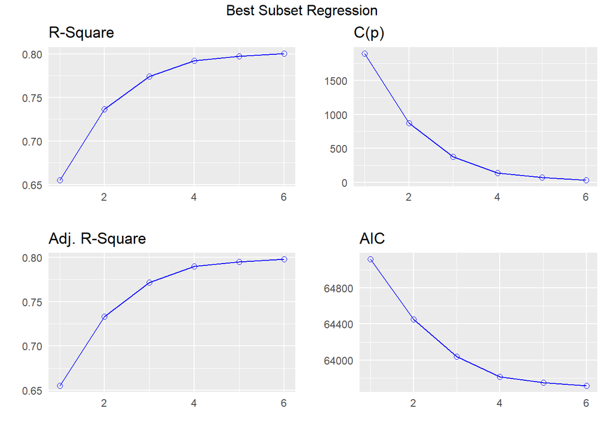

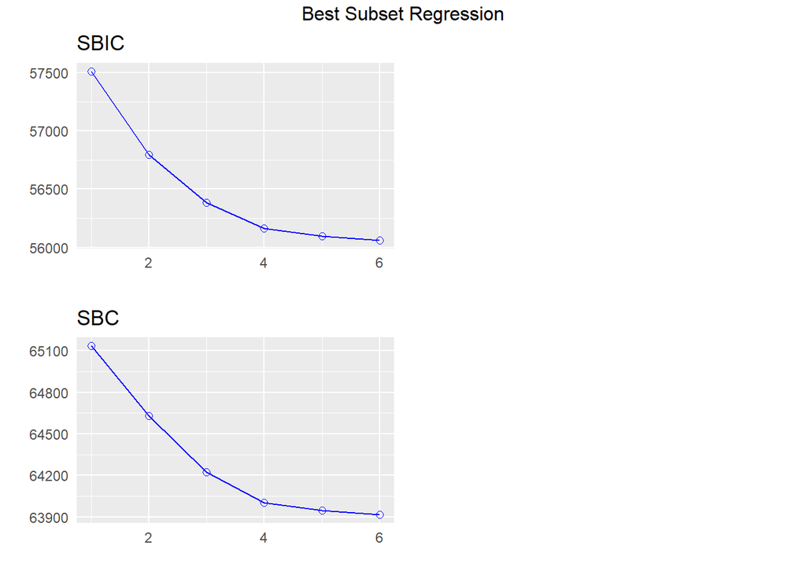

As seen by the SBIC and SBC plots, the attributes containing the strongest correlations include `OverallQual`, `Neighborhood`, and `LotArea`

# Part 4: Regression Diagnostics

As seen from the previous milestone, a model including `OverallQual`, `Neighborhood` and `LotArea` is the most efficient way to predict `SalePrice`. Here we are creating a linear regression model including these very attributes. In this milestone we will analyze the necessary diagnostic plots associated with this model.

#### Residuals vs. Fitted Plot:

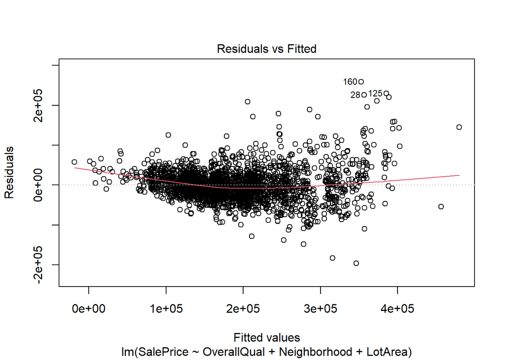

#### Q-Q Residuals:

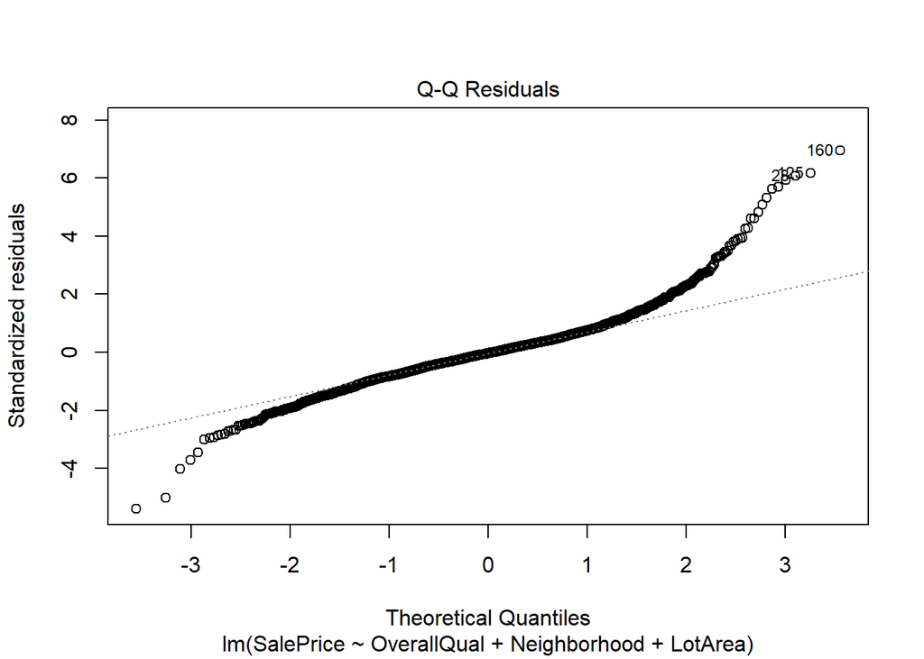

The Q-Q Residuals graph allows comparison between the spread of our sale price predictions against a normal distribution. Ideally, all the dots on this graph would align with the dashed line.

Many of our predictions align well, especially for the majority of homes around the average price. However, there are some houses where the model’s predictions are less accurate. As seen in the previous plot, the culprit is yet again; high-priced homes. This may suggest that these homes have unique characteristics were not captured by them model, such as special features or locations, which makes them stand out from the average home.

#### Scale-Location Plot:

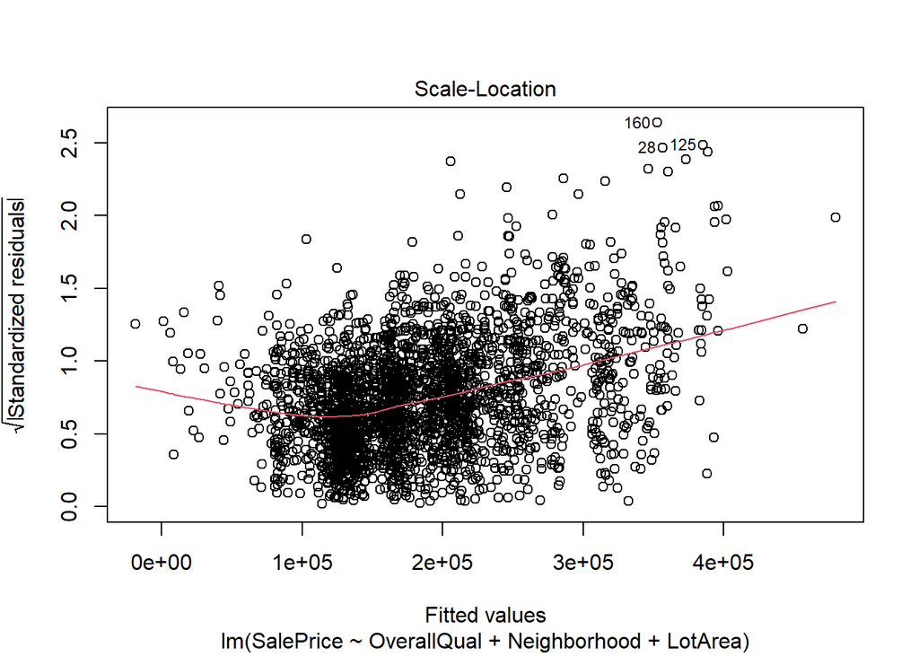

The Scale-Location will helps check if the model’s performance is consistent for cheap, moderately priced, and expensive homes. The dots show whether the predictions are too high or too low across different price levels. Ideally, these dots would be scattered evenly without forming any patterns. However, when we move to higher-priced homes, our predictions vary more. This emphasizes that our model is less reliable for predicting the prices of more expensive homes.

#### Residuals vs. Leverage Plot:

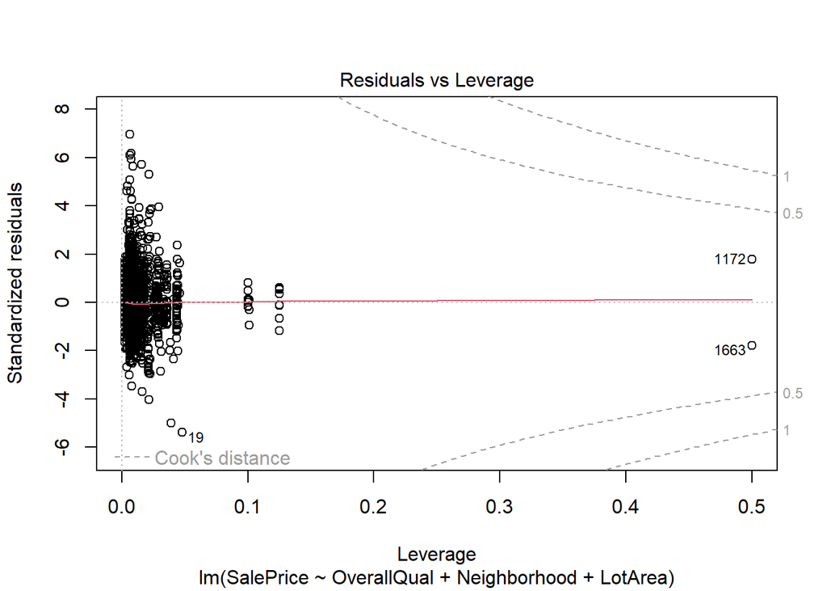

The Residuals vs. Leverage graph helps identify any individual houses that could be ‘over-influencing’ our predictions. Ideally, all the houses would be clustered indicating they all equally influence the model. However, some points stand out on the right side of the graph, indicating that they are unusually influential compared to the average home.

# Conclusion

Overall, this model can serve as a valuable tool for real estate investors, policymakers, and urban planners in making informed decisions. It also sets a foundation for future research, where more complex models and data from additional years could provide even deeper insights.